# ds202_HW5

Xinyi Zhu

4/9/2020

```r
dat <- readr::read_csv("2019_Iowa_Liquor_Sales.csv")
library(tidyverse)
library(lubridate)
```

```r
library(ggplot2)
library(dplyr)
```

2. Data cleaning:
1. extract geographic latitude and longitude from the variable `Store Location`

```r
storeLocation <- dat[, "Store Location"]
storeLocation <- separate(storeLocation, "Store Location", into = c("latitude", "longtitude"), sep = " (?=[^ ]+$)")

storeLocation$latitude<- gsub("POINT \\(", "", storeLocation$latitude)
storeLocation$longtitude<- gsub("\\)", "", storeLocation$longtitude)
dat$`Store Location` <- storeLocation
a <- dat
```

2. make sure the variables are in the correct type, by converting incorrect variable types.

```r
a$`Store Location`$latitude= as.double(a$`Store Location`$latitude)
a$`Store Location`$longtitude= as.double(a$`Store Location`$longtitude)
a$`Vendor Number` = as.numeric(a$`Vendor Number`)
a$`State Bottle Cost`=as.numeric(a$`State Bottle Cost`)
a$`Volume Sold (Gallons)`=as.numeric(a$`Volume Sold (Gallons)`)
str(a)
```

```
## Classes 'spec_tbl_df', 'tbl_df', 'tbl' and 'data.frame': 63103 obs. of  24 variables:
##  $ Invoice/Item Number  : chr  "INV-16712000040" "INV-16712000012" "INV-16712000070" "INV-16712000009" ...
##  $ Date                 : chr  "01/03/2019" "01/03/2019" "01/03/2019" "01/03/2019" ...
##  $ Store Number         : num  2500 2500 2500 2500 2500 ...
##  $ Store Name           : chr  "Hy-Vee Food Store #1 / Ames" "Hy-Vee Food Store #1 / Ames" "Hy-Vee Food Store #1 / Ames" "Hy-Vee Food Store #1 / Ames" ...
##  $ Address              : chr  "3800 W Lincoln Way" "3800 W Lincoln Way" "3800 W Lincoln Way" "3800 W Lincoln Way" ...
##  $ City                 : chr  "Ames" "Ames" "Ames" "Ames" ...
##  $ Zip Code             : num  50010 50010 50010 50010 50010 ...
##  $ Store Location       :Classes 'tbl_df', 'tbl' and 'data.frame':   63103 obs. of  2 variables:
##   ..$ latitude  : num  NA NA NA NA NA NA NA NA NA NA ...
##   ..$ longtitude: num  NA NA NA NA NA NA NA NA NA NA ...
##  $ County Number        : num  85 85 85 85 85 85 85 85 85 85 ...
##  $ County               : chr  "STORY" "STORY" "STORY" "STORY" ...
##  $ Category             : num  1042100 1012100 1031100 1012100 1081400 ...
##  $ Category Name        : chr  "Imported Dry Gins" "Canadian Whiskies" "American Vodkas" "Canadian Whiskies" ...
##  $ Vendor Number        : num  260 260 55 260 65 205 330 434 260 85 ...
##  $ Vendor Name          : chr  "DIAGEO AMERICAS" "DIAGEO AMERICAS" "SAZERAC NORTH AMERICA" "DIAGEO AMERICAS" ...
##  $ Item Number          : num  28867 11294 37936 10805 82867 ...
##  $ Item Description     : chr  "Tanqueray Gin" "Crown Royal" "Skol Vodka" "Crown Royal Regal Apple" ...
##  $ Pack                 : num  12 24 12 24 12 12 6 6 12 12 ...
##  $ Bottle Volume (ml)   : num  1000 375 750 375 1000 750 1750 1750 750 375 ...
##  $ State Bottle Cost    : num  15.5 8 3.64 8 7.87 ...
##  $ State Bottle Retail  : num  23.25 12 5.46 12 11.81 ...
##  $ Bottles Sold         : num  12 4 12 4 12 3 6 12 2 4 ...
##  $ Sale (Dollars)       : num  279 48 65.5 48 141.7 ...
##  $ Volume Sold (Liters) : num  12 1.5 9 1.5 12 2.25 10.5 21 1.5 1.5 ...
##  $ Volume Sold (Gallons): num  3.17 0.39 2.37 0.39 3.17 0.59 2.77 5.54 0.39 0.39 ...
##  - attr(*, "spec")=
##   .. cols(
##   ..   `Invoice/Item Number` = col_character(),
##   ..   Date = col_character(),
##   ..   `Store Number` = col_double(),
##   ..   `Store Name` = col_character(),
##   ..   Address = col_character(),
##   ..   City = col_character(),
##   ..   `Zip Code` = col_double(),
##   ..   `Store Location` = col_character(),
##   ..   `County Number` = col_double(),
##   ..   County = col_character(),
##   ..   Category = col_double(),
##   ..   `Category Name` = col_character(),
##   ..   `Vendor Number` = col_character(),
##   ..   `Vendor Name` = col_character(),
##   ..   `Item Number` = col_double(),
##   ..   `Item Description` = col_character(),
##   ..   Pack = col_double(),
##   ..   `Bottle Volume (ml)` = col_double(),
##   ..   `State Bottle Cost` = col_double(),
##   ..   `State Bottle Retail` = col_double(),
##   ..   `Bottles Sold` = col_double(),
##   ..   `Sale (Dollars)` = col_double(),
##   ..   `Volume Sold (Liters)` = col_double(),
##   ..   `Volume Sold (Gallons)` = col_double()
##   .. )
```

3. extract year, month and day from the variable `Date` as separate columns.

```r
b <- a %>% separate('Date', into = c("month","day","year"))
head(b)
```

```
## # A tibble: 6 x 26
##   `Invoice/Item N… month day   year  `Store Number` `Store Name` Address City
##   <chr>            <chr> <chr> <chr>          <dbl> <chr>        <chr>   <chr>
## 1 INV-16712000040  01    03    2019            2500 Hy-Vee Food… 3800 W… Ames
## 2 INV-16712000012  01    03    2019            2500 Hy-Vee Food… 3800 W… Ames
## 3 INV-16712000070  01    03    2019            2500 Hy-Vee Food… 3800 W… Ames
## 4 INV-16712000009  01    03    2019            2500 Hy-Vee Food… 3800 W… Ames
## 5 INV-16712000160  01    03    2019            2500 Hy-Vee Food… 3800 W… Ames
## 6 INV-16712000119  01    03    2019            2500 Hy-Vee Food… 3800 W… Ames
## # … with 19 more variables: `Zip Code` <dbl>, `Store Location`$latitude <dbl>,
## #   $longtitude <dbl>, `County Number` <dbl>, County <chr>, Category <dbl>,
## #   `Category Name` <chr>, `Vendor Number` <dbl>, `Vendor Name` <chr>, `Item
## #   Number` <dbl>, `Item Description` <chr>, Pack <dbl>, `Bottle Volume
## #   (ml)` <dbl>, `State Bottle Cost` <dbl>, `State Bottle Retail` <dbl>,
## #   `Bottles Sold` <dbl>, `Sale (Dollars)` <dbl>, `Volume Sold (Liters)` <dbl>,
## #   `Volume Sold (Gallons)` <dbl>
```

3. First overview:
1. Plot a scatterplot of lat and long of store locations.

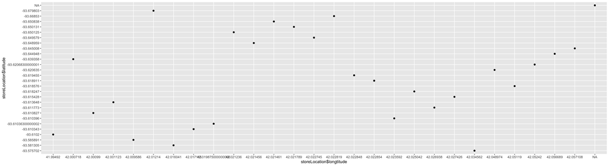

```r
ggplot(b, aes(x=storeLocation$longtitude, y=storeLocation$latitude)) + geom_point()
```

2. Provide a visual breakdown of the liquor category (by `Category Name`). Include volume sold in the breakdown.

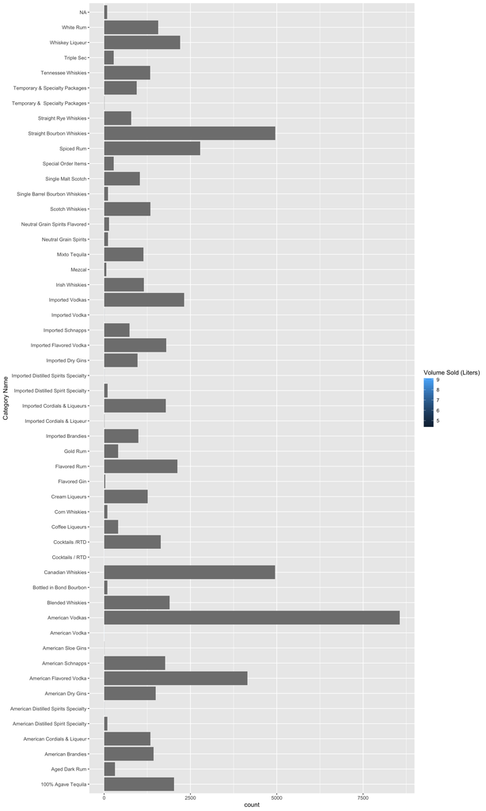

```r
b %>%ggplot(aes(x = `Category Name`, fill = `Volume Sold (Liters)`)) + geom_bar()+ coord_flip()
```

4. Find the daily sales liquor sales in Ames in 2019. Summarize the number of sales, volume of liquor sold, and amount of money spent.

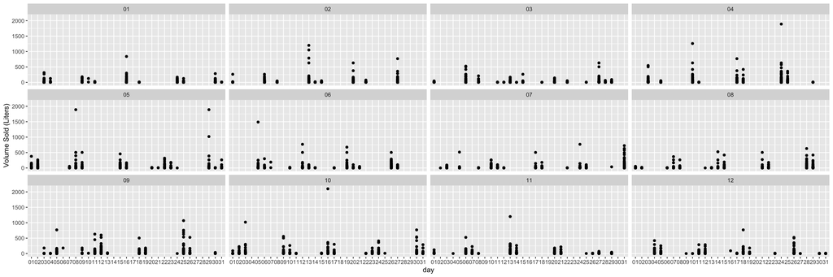

```r
b %>%
  group_by(`Bottles Sold`) %>%
  ggplot(aes(x=day, y=`Volume Sold (Liters)`)) + geom_point() +facet_wrap(~month)
```